# TwitterAnalysis_CrewDragonSpaceX

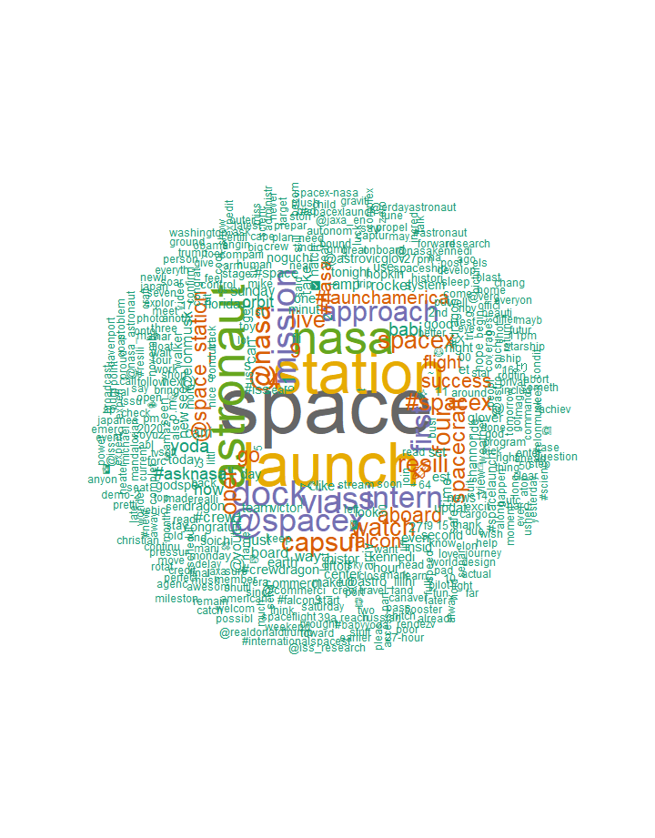

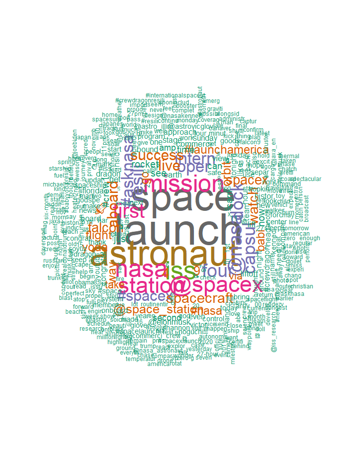

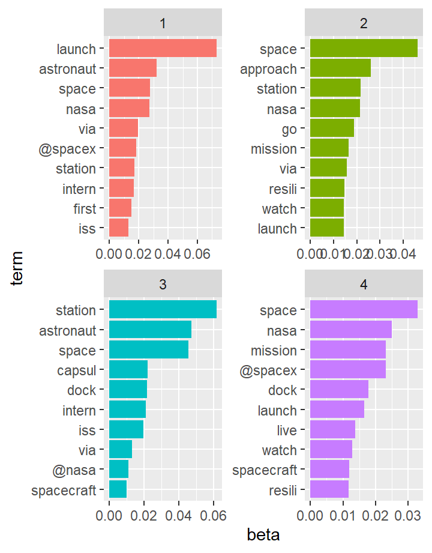

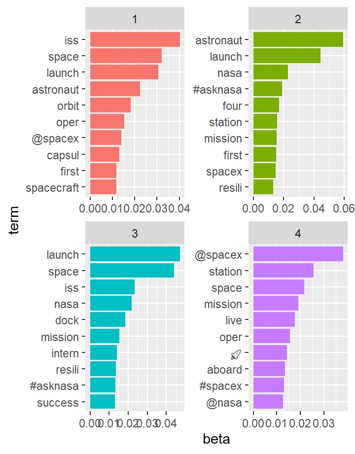

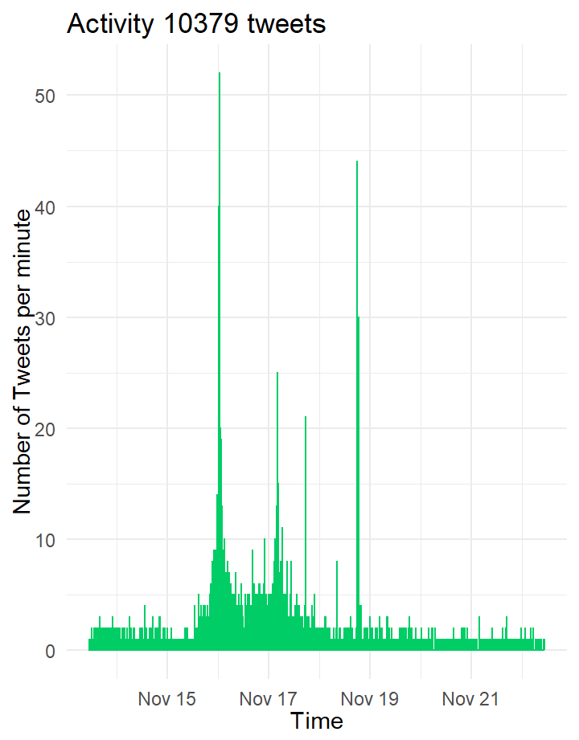

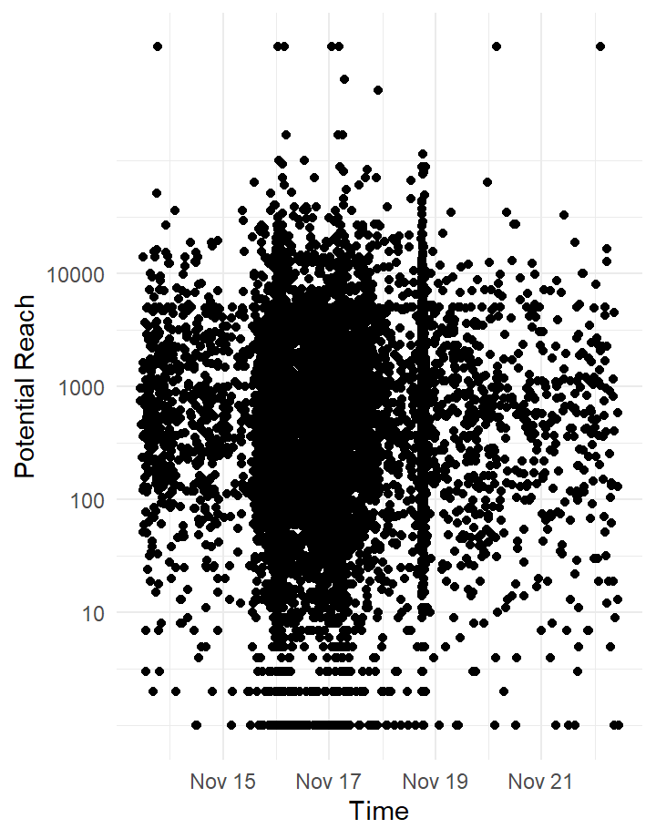

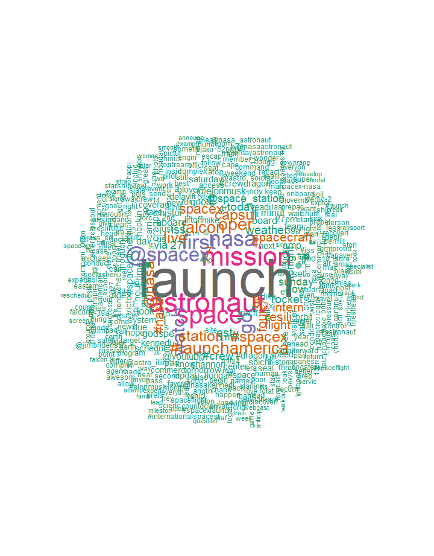

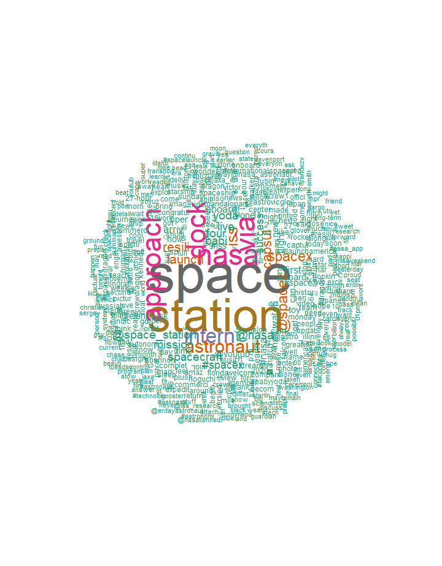

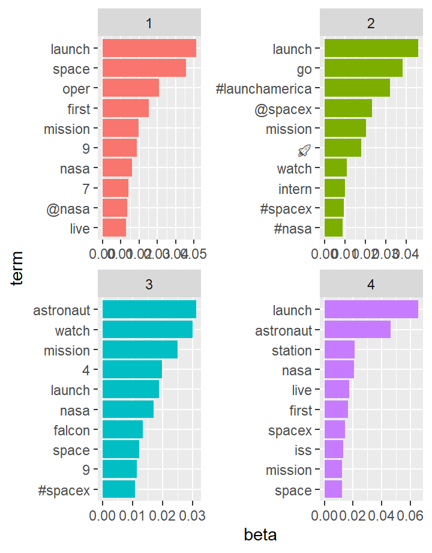

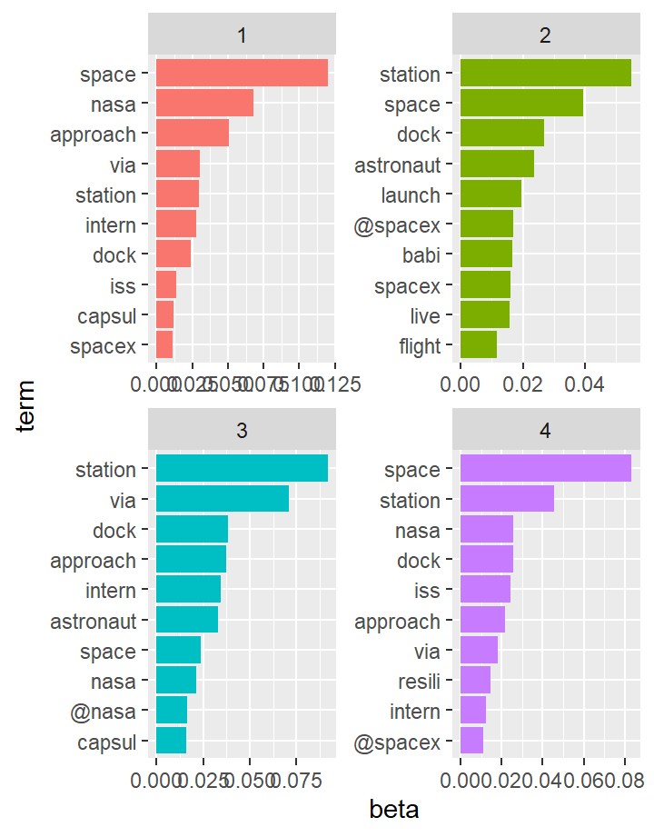

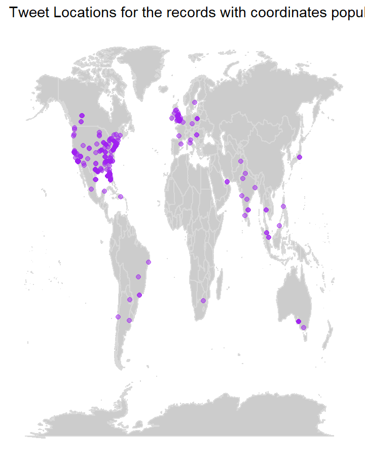

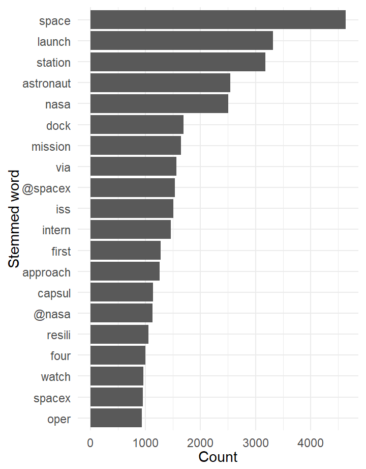

[2 more figures not shown]

# Intro

Twitter Analysis for CrewDragon, In this presentation we cover below topics

- Introduction
- Hypothesis
- Analysis and Infographics
- Conclusion

# Introduction

## Picture

[figure not shown]

*Fig 1.1 Crew Dragon Resilience (Dragon C207)*

**Introduction:**

This report analyzes the twitter data of [crewDragonSpaceX.](https://en.wikipedia.org/wiki/SpaceX_Dragon_2)

## Introduction

**CrewDragon:**

Crew Dragon, a space capsule capable of ferrying up to seven astronauts, and Cargo Dragon, an updated replacement for the original Dragon spacecraft.

[Crew Dragon Resilience (Dragon C207)](https://en.wikipedia.org/wiki/Crew_Dragon_Resilience) is currently docked on orbit to the International Space Station (ISS) on the Crew-1 mission after launch at 00:27 UTC on November 16, 2020, resilience docked autonomously to the station at 04:01 UTC on Day 2 (November 17th, 2020) of the mission marking the first crewed operational flight of a Crew Dragon craft.

**Data:**

# Hypothesis

## Column1

**Hypothesis:**

Public and media would be excited to see the first commercial program which carries the astronauts to International space station. And speaks about it successful docking to the space station.

**Method:**

Collect the tweet before and after the launch of spacecraft, the tweets collected were without retweets and only the original tweets.

# Analysis and Infographics

### Data Summary

Quick summary of the data , which will be used for analysis

| TotalTweets | start_timestamp | end_timestamp | retweet_count | favorite_count |
| --- | --- | --- | --- | --- |
| 10379 | 2020-11-13 10:51:19 | 2020-11-22 10:38:19 | 116013 | 950614 |

### WordCloud for the Complete Tweet Texts

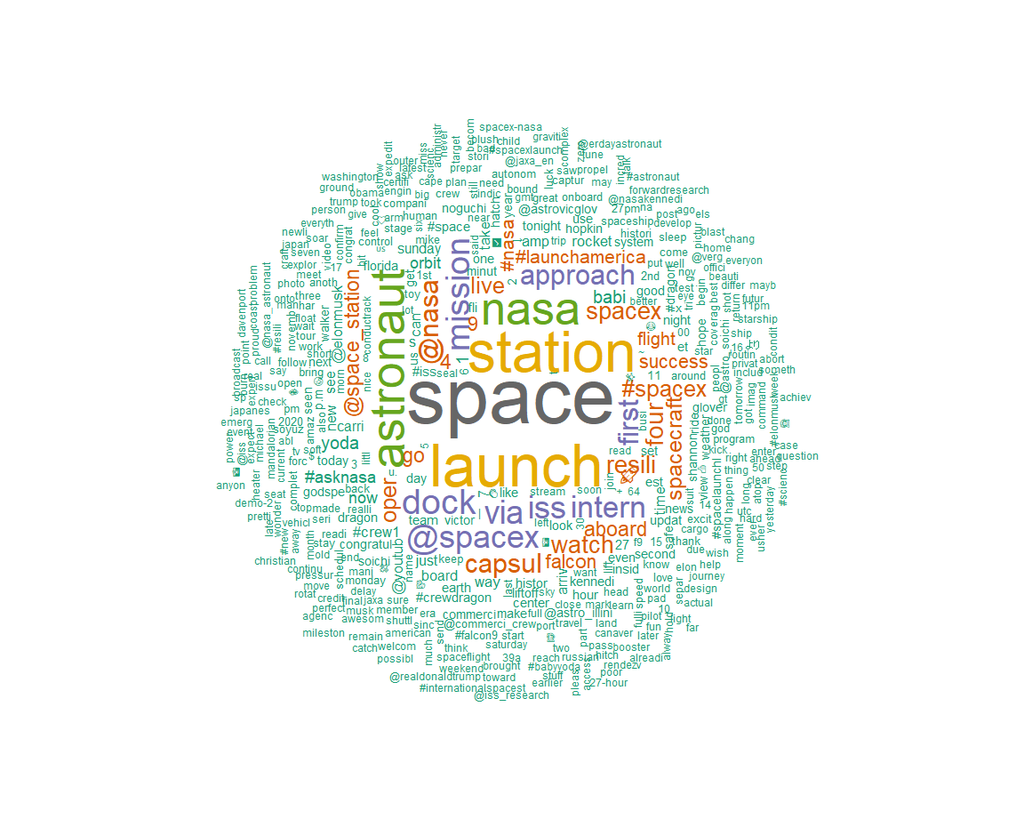

### WordCloud for Tweet Texts After launch of Crew Dragon and before docking

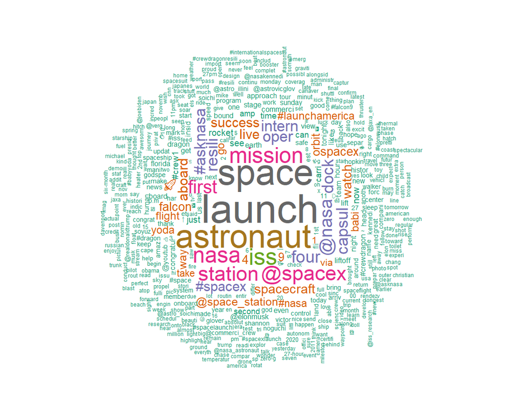

### Topic Modeling for the Complete Tweet Texts, 4 topics

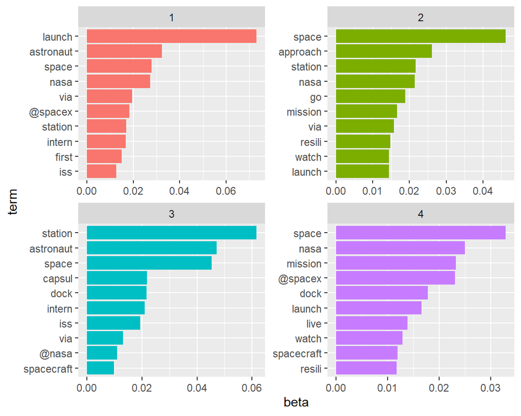

### Topic Modeling for Tweet Texts After launch of Crew Dragon and before docking, 4 topics

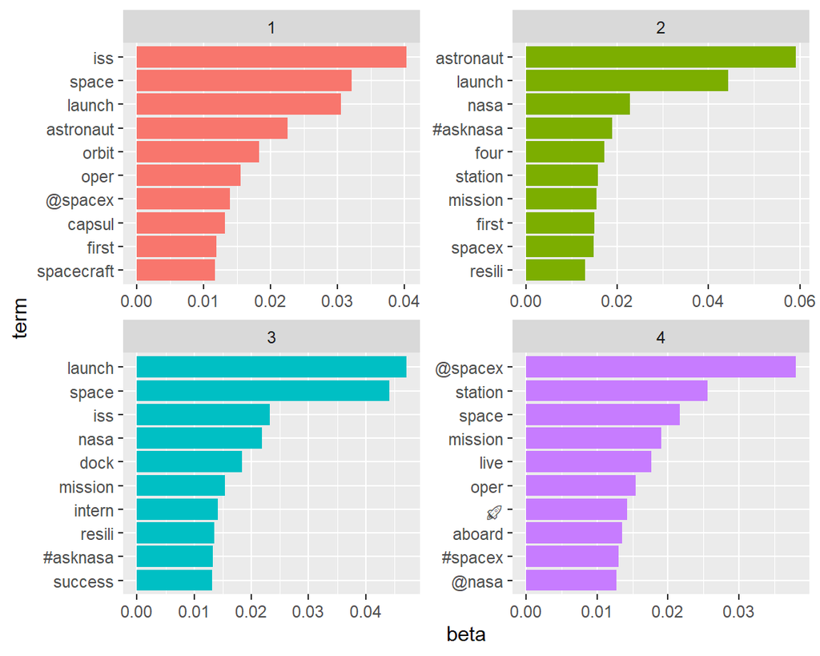

### Tweets Per Minute

No. of tweets per minute about crewDragon

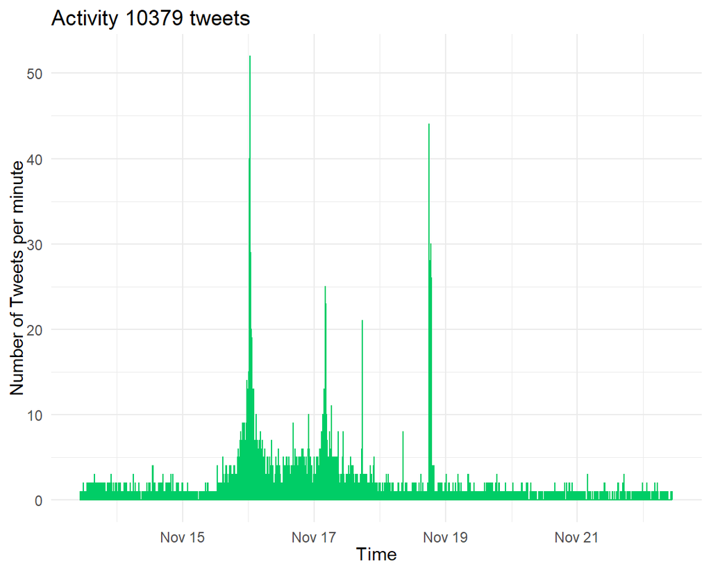

### Top10 shared URL,their retweetcount and favoritecount

| urls_url | TweetCount | RetweetCount | favoriteCount |
| --- | --- | --- | --- |
| ift.tt/2HcinBp | 941 | 28 | 448 |
| washingtonpost.com/technology/202… | 207 | 198 | 3291 |
| twitter.com/SpaceX/status/… | 174 | 83 | 544 |
| theverge.com/2020/11/16/215… | 134 | 130 | 1206 |
| twitter.com/NASA/status/13… | 109 | 873 | 8909 |
| theguardian.com/science/2020/n… | 79 | 38 | 199 |
| cnn.com/2020/11/15/tec… | 76 | 23 | 263 |
| youtu.be/rDEcVPCoYIA | 70 | 13 | 55 |
| space.com/spacex-crew-1-… | 69 | 15 | 95 |
| spaceflightnow.com/2020/11/15/spa… | 60 | 2556 | 13531 |

### Reachability per tweet

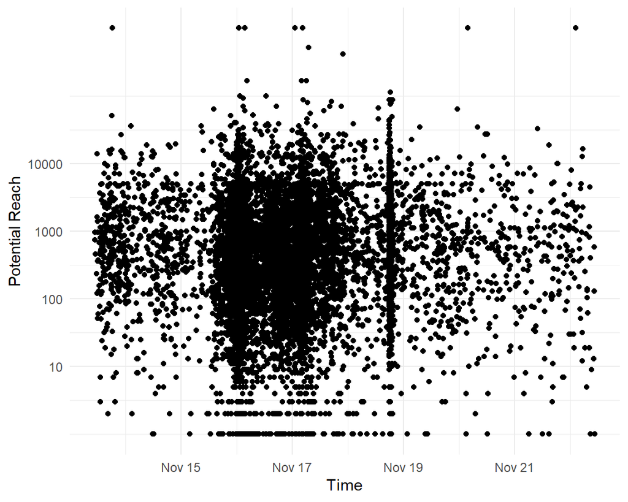

### WordCloud for the Tweet texts before Launch

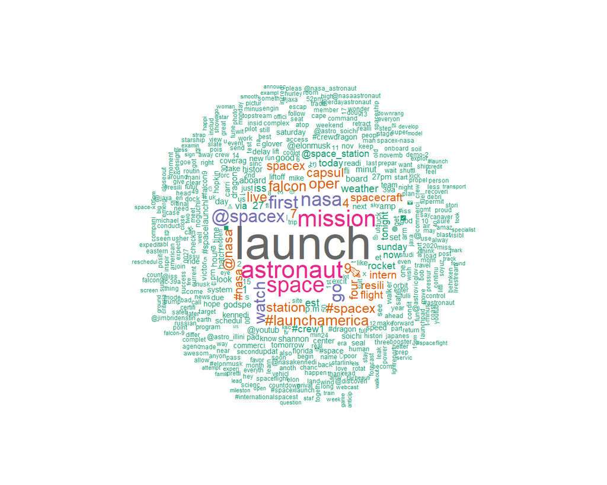

### WordCloud for the Tweet texts after docking

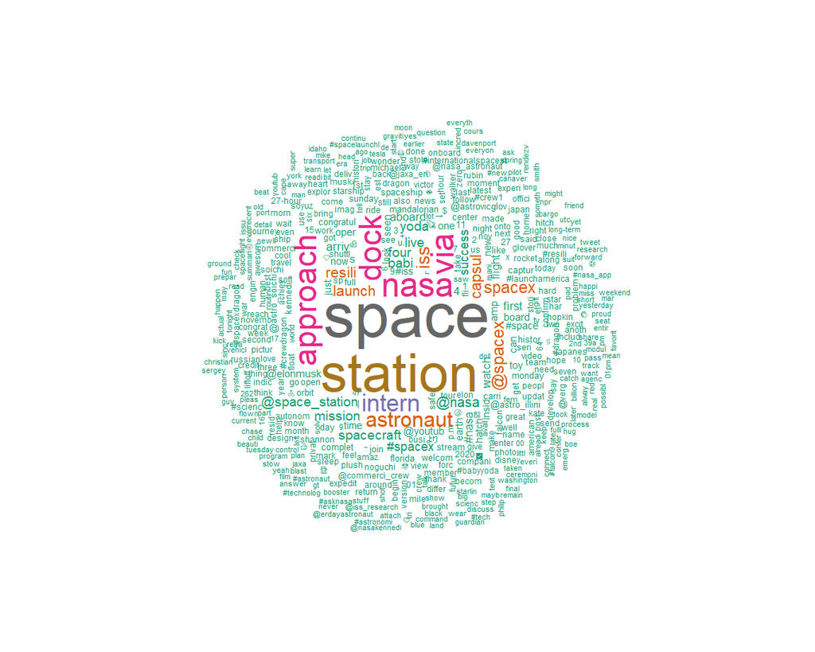

### Topic Modeling for the Tweet texts before Launch, 4 topics

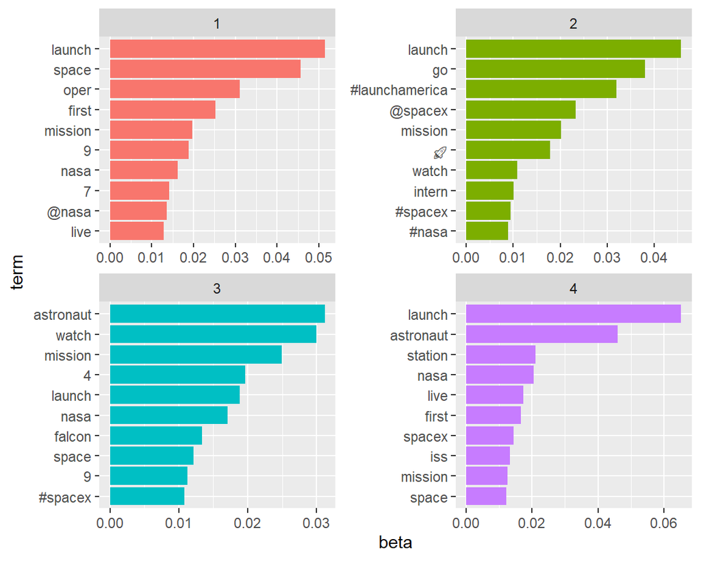

### Topic Modeling for Tweet texts after docking, 4 topics

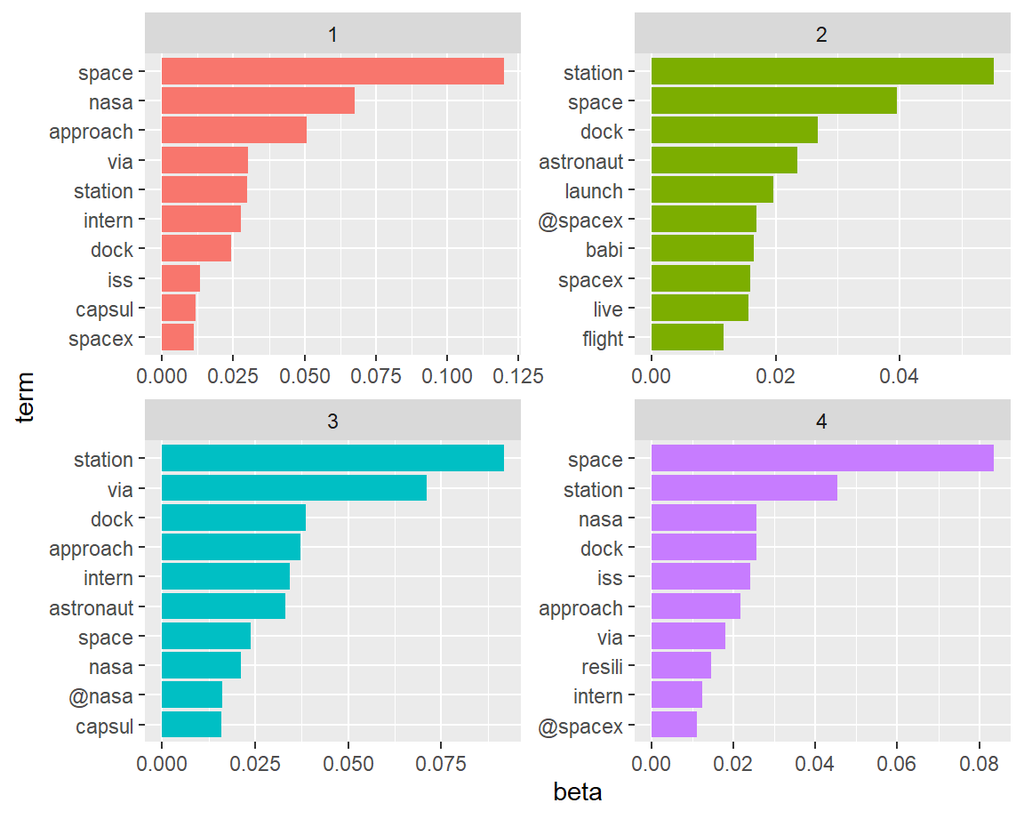

### Tweet Locations

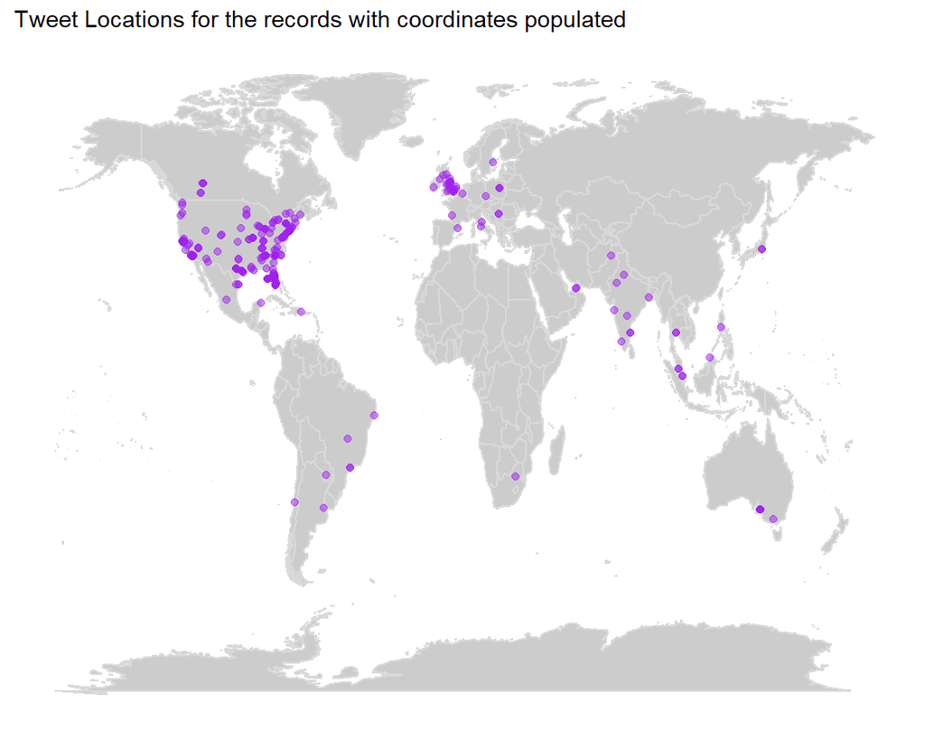

### StemmedWords

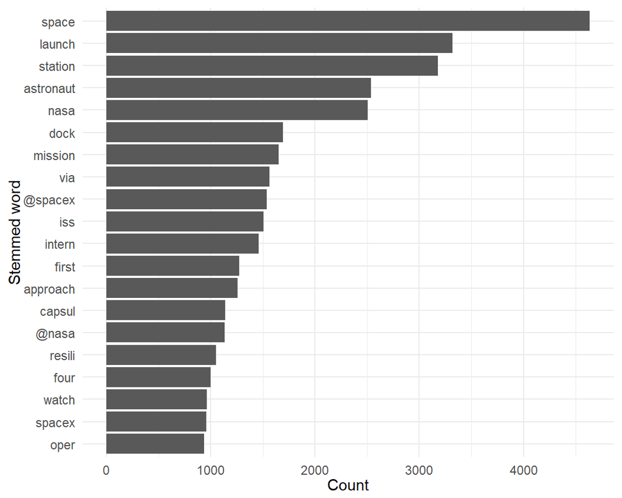

### 3-grams occurrences

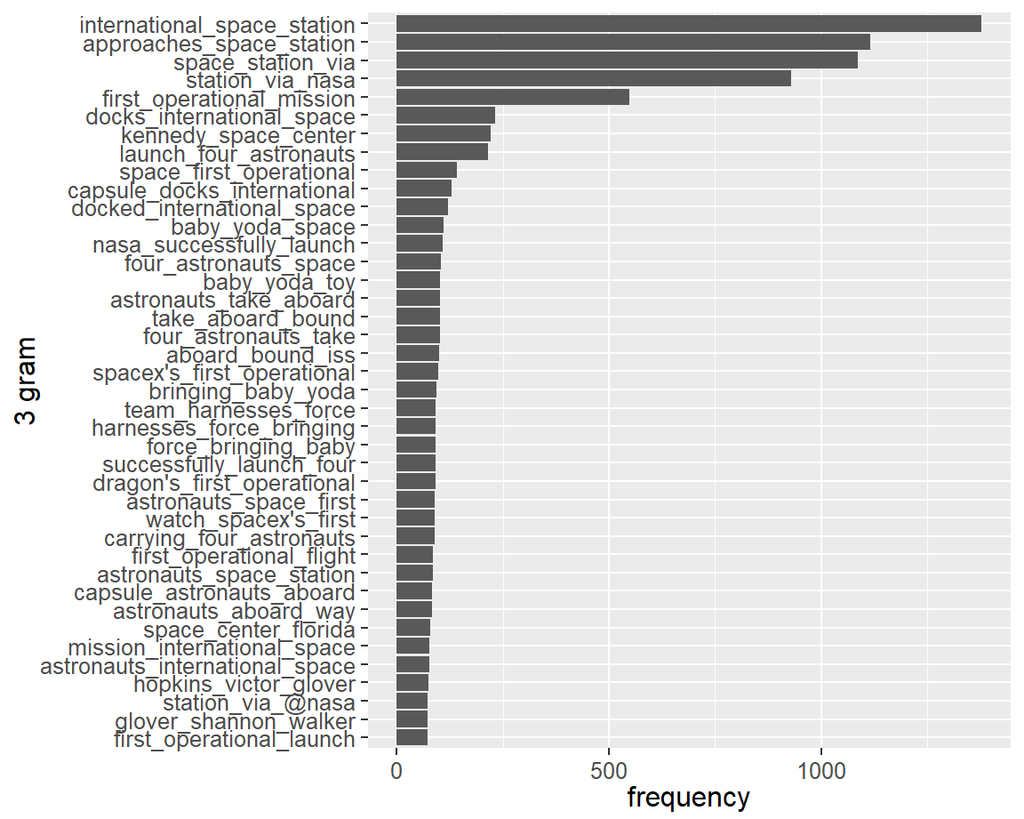

### Sentimental analysis

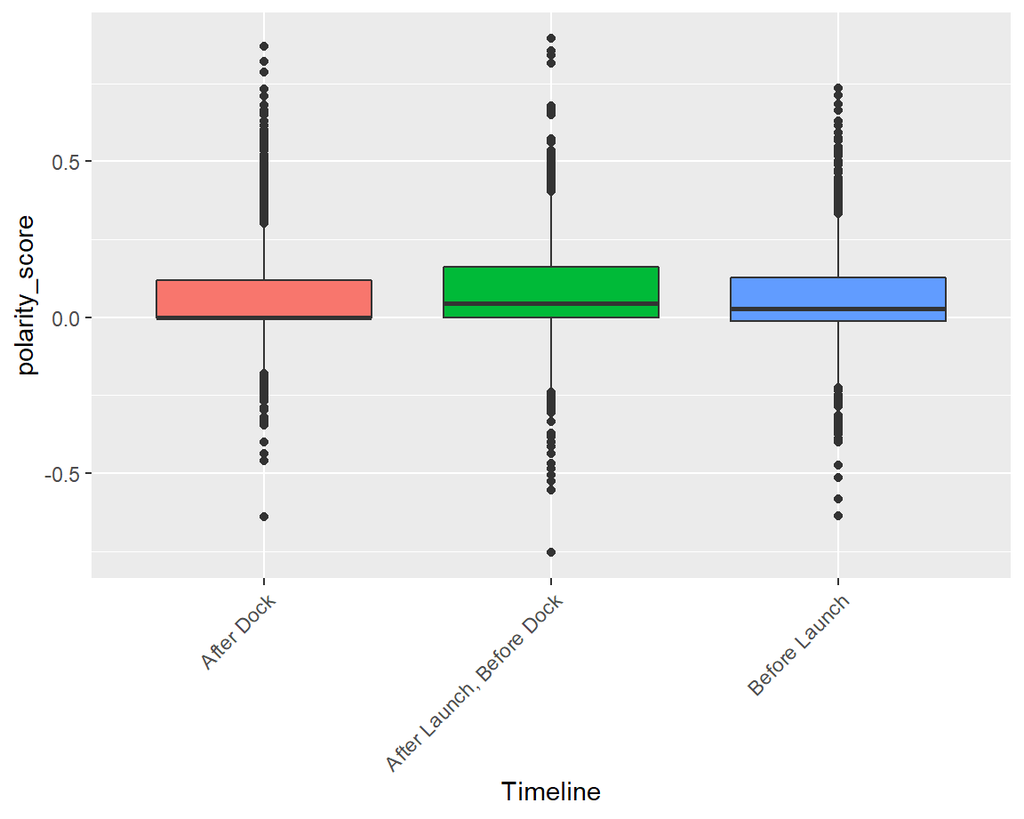

# Conclusion

## Column1

**Conclusion:**

In twitter media, there are more tweets during the time of launch and docking, i.e on the 16th November and 17th November. People are speaking more about Nasa, SpaceX, Success, First Mission, America etc. People are more sentimental towards its success and infact americans shows their patriotism by praising America on the tweets.

Secondly, only developed and developing nations where speaking most on this topic . Number of tweets are not more from Asia , Africa and South America continents.

[video not shown]